# What a Census Can and Cannot Do

The one thing nothing else can do, and what it cost to keep doing it

Democracy’s Data

Last updated September 13, 2026 at 10:53a EDT

There are two ways to learn about a country. **Eliciting** asks some people questions; **enumerating** tries to count everyone. This chapter is about the second. A census is an attempt at a row for every person at every address, and that attempt, not any particular table it produces, is what the rest of this section rests on. The surveys chapter takes up the first way.

A census is also the only instrument in this book that the Constitution requires. Article I orders an “actual Enumeration” every ten years, for one purpose: dividing the House of Representatives among the states.[^1] Everything else the census is used for, which is nearly everything, is a by-product of that obligation.

The obligation is expensive to honor. The 2020 count cost about $15.6 billion through 2023, by the Government Accountability Office’s accounting, most of it spent finding the households that did not answer on their own. The decennial chapter works that figure out per person counted.

This chapter reads the 2020 census file for one state, Georgia, and asks three questions of it. What can an enumeration do that no survey can? What else does the same agency publish under the same name? And how close is the published file to the count that was actually taken? The answer to the last question is the strangest fact in this section.

## Where the data comes from, and what it is for

The **Census Bureau**, a statistical agency inside the Department of Commerce, conducts the count and publishes everything built on it. The file this chapter reads is the 2020 **P.L. 94-171 redistricting file** for Georgia — P.L. for Public Law, the number of the 1975 statute that requires it[^2] — the small-area counts the law obliges the Bureau to hand every state so the state can redraw its districts. It is the census at its finest grain, which makes it the right file for a chapter about what an enumeration is.

**Who is in it, and how they got there.** Everyone residing in the United States on 1 April 2020, at the address the Bureau’s residence rules assign them. Nobody volunteers into a census and nobody may opt out: answering is required by law, under the same section of the federal code that makes refusing the American Community Survey an offence.[^3] The Bureau builds a list of every address in the country, invites each household to respond, and sends people to the doors that stay silent. Whoever that operation fails to find is missing from the file, and the misses do not fall evenly — the coverage brief reads the Bureau’s own grade on itself.

**Who it was made for.** Congress, first: the state totals divide the 435 House seats, which is the constitutional job. The fifty state legislatures, second: this particular file exists because a 1975 law obliges the Bureau to deliver block-level counts for redistricting within a year of the count. Everyone else is a third party reading a legal record as a statistic: the agencies allocating money, the researchers, and this book.

**What it costs to get.** Nothing, to you. The Bureau publishes the file for every state on its download server, at https://www2.census.gov/programs-surveys/decennial/2020/data/01-Redistricting_File--PL_94-171/, as plain text files anyone can open, with no account and no key; the Georgia file here is the same one the areal-units chapter uses. What cost fifteen billion dollars was making it.

**What has already been done to it.** The published counts below the state level are deliberately not the collected counts. Before release, the Bureau ran the file through a formal privacy system, which it calls differential privacy, that adds a small random amount to every small-area number — something it had never done at this scale before 2020.[^4] The state totals were held exact. The end of this chapter shows why you have to take the alteration on the Bureau’s word: no audit of the file can find it.

## What the Bureau publishes, and where it lives

Three of the 134 get almost all of this book, and the selection rule is confusability rather than importance. Each of the three answers some version of *how many people live here*. Each publishes a figure formatted like a population, under the same agency’s name, on the same website. Nobody has ever quoted the Commodity Flow Survey and meant a headcount, because nothing about the two looks alike. These three get quoted interchangeably constantly, and they are not the same.

| The question | Decennial census | American Community Survey | Population estimates |
| --- | --- | --- | --- |
| How many people live on this block? | Yes – this is the one thing only it can do | No – the sample is far too thin | No |
| How many people moved from Ohio to Georgia last year? | No – it does not ask | Yes, with a margin often larger than the estimate | No |
| How many people live in this county today? | No – it is ten years old the day after it is taken | Yes, as a five-year average centred on the past | Yes – this is what it is for |
| What is the population of the United States, exactly? | As of one day, every ten years, subject to undercount | No – it is a sample | No – it is a model carried forward from the last census |
| How many people here speak Spanish and little English? | No – the short form does not ask | Yes – this is what it is for | No |
| Is this number exact? | No – noise is added below the state level | No – and it prints its own margin of error | No – it is a projection and is revised |

The **decennial census** is the enumeration: everyone, one day, every ten years. The **American Community Survey** is a survey of about 3.5 million addresses a year. Beside every number it publishes a **margin of error** — a stated range for how far off that estimate could be. The **population estimates** collect nothing from anybody; they carry the last count forward with births, deaths and migration. Each instrument has a chapter of its own in this section: the decennial census, the ACS, and the estimates. One oddity is argued out in the section introduction and only noted here: the ACS is a survey, and it sits in this counting section because answering it is compulsory.

What the confusion costs is easiest to see where the margins are large. These are the Bureau’s own published state-to-state migration flows, from the ACS:

[output not shown]

Everything the three instruments publish sits on one geographic skeleton — nation, then state, county, tract (a neighbourhood-sized area of a few thousand people), block group, and block (often a single city block) — and every published figure is a figure for one of those boxes. The geography chapter is about that skeleton. Access comes in three forms, each with a brief of its own. You can point and click through tables at data.census.gov, or have a program ask for the same tables at api.census.gov, which the API brief is about. Or you can take the plain files on the Bureau’s download server, which the access brief walks shelf by shelf.

Even “the population of a state in 2020” turns out to be a choice between published products:

| Population | Value | What it is for |
| --- | --- | --- |
| Resident population, 2020 census | 10,711,908 | Redistricting, funding formulas, every rate with a population denominator |
| Apportionment population, 2020 census | 10,725,274 | Dividing the 435 House seats among the states |
| Difference | 13,366 | Federal employees and their dependents stationed overseas, allocated to a home state for apportionment only |

Georgia’s 2020 population is 10,711,908. It is also 10,725,274. Both figures are official, both come from the 2020 census, and they differ by 13,366 people. Those are federal employees and their dependents stationed overseas, assigned to a home state for dividing House seats and to no state for any other purpose.[^5]

Neither figure is wrong. They answer two different legal questions, and a rate built on the wrong one has silently changed the question. This is the book’s recurring problem in its most official form: a **denominator** that nobody states — the bottom number of the fraction, the thing you divide by.

### What arrives

```
The P.L. 94-171 file arrives as four pipe-delimited files with no
header row. A block's population is in segment 1; who those people
are by race is further along the same line; the block's NAME and
location are in a fourth file, joined on a record number that is
unique within a state and means nothing outside it.

Three real Georgia blocks, after the join, as the derived extract
stores them:

GEOID20  pop  black_alone  black_any  vap  black_any_vap
130670306032011  15  1  4  12  1
131590105031067  25  3  3  16  0
130771703031017  36  0  2  34  0

GEOID20 is fifteen characters and must be read as text. As a number
it loses its leading zero and stops being a Georgia block at all.

Every count above is a published count. It is not necessarily the
count that was collected -- see the chapter.
```

## What only an enumeration can do

Here is what the 2020 census resolves to in one state.

| Quantity | Value |
| --- | --- |
| Blocks in Georgia | 232,717 |
| Blocks with nobody in them | 67,384 |
| Blocks with at least one person | 165,333 |
| Median population of a populated block | 26 |
| Blocks containing exactly one person | 2,457 |
| Blocks containing fewer than ten people | 33,374 |
| Share of Georgians living in blocks of fewer than ten | 1.7% |
| Total population, summed from blocks | 10,711,908 |

232,717 blocks in Georgia. The median populated one — line up every block that holds anybody from smallest to largest, and take the one in the middle — holds 26 people. **2,457 of them contain exactly one person.**

No sample can do this, and the reason is arithmetic rather than effort. A national survey of sixty thousand people, spread across the whole country, places roughly nobody on any given block. It is not a matter of funding a bigger survey. There is no sample size at which a sample becomes an enumeration.

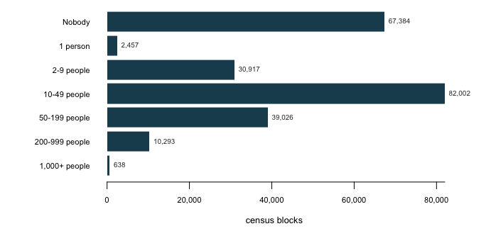

**Figure 1. Georgia’s 232,717 census blocks, sorted by how many people the file says live on each.** The question this chart answers is *how many blocks are that small*: one count per size band. That is what a bar chart is for — each band gets a bar, and the bar’s length is the count. The longest bar is the 10-49 people band, with 82,002 blocks; 67,384 blocks hold nobody at all, and 2,457 hold a single person. Hover a bar for how many Georgians live in blocks of that size.

The census is, mostly, a file of very small numbers. That capability is load-bearing for the rest of this book. Every district line is drawn by assembling blocks. Every rate with a population on the bottom of the fraction needs a count of the people in a place, and that count comes from here or it comes from nowhere.

## The published count is not the collected count

The same capability is a privacy problem. A file that can describe a block of 26 people by race and age can also identify them, and 2,457 Georgia blocks contain exactly one person. So in 2020 the Bureau added noise to the published counts below the state level, and the counts you have been reading in this chapter are not, exactly, the counts the Bureau collected. Two things about that are worth verifying from the file rather than taking on faith.

**First, the state total is exact.** Sum all 232,717 noised Georgia block counts and you get 10,711,908 — the published resident population, to the person. The top of the hierarchy is held fixed and the noise beneath it is constrained to sum back to it.

**Second, and this is the part that matters: you cannot find the noise.**

| Consistency check | Violations | Blocks checked |
| --- | --- | --- |
| Blocks where voting-age population exceeds total population | 0 | 232,717 |
| Blocks where Black population exceeds total population | 0 | 232,717 |
| Blocks where Black voting-age population exceeds Black population | 0 | 232,717 |
| Blocks with a negative count in any field | 0 | 232,717 |

Every internal check passes. Not one block has more voting-age people than people. Not one has more Black residents than residents. Not one negative count, in 232,717 blocks. A reader who suspected the file had been altered and went looking for impossibilities would find none, and would conclude, reasonably and wrongly, that nothing had been done to it.

The noise is real, it is documented, and it is invisible from inside the data. **The only reason anyone knows the published counts differ from the collected counts is that the Bureau said so.** No audit of the file recovers that fact.

This is the strongest possible version of a lesson that runs through the whole book. A file’s trustworthiness is not a property you can test for by staring at the numbers. It is a property of the institution that produced it, and of what that institution chose to tell you.

## What this data cannot tell you

The block statistics are Georgia’s. Block counts, sizes and the share of one-person blocks differ by state, and a rural state would look different from this one. The arithmetic that makes small areas impossible for a sample does not differ.

**The other 131 programs are not covered.** Three instruments were chosen because they are the three that get confused with each other, not because they are the three that matter. If a question is about housing conditions, commuting, crime victimisation or business receipts, the answer is on the Bureau’s list and not in this chapter. The Survey Explorer is the place to find which survey asks it. That list also changes, and the count of 134 is what the tool showed when this chapter was written.

**Nothing here measures the undercount.** A census attempts to count everyone and does not succeed; coverage error is estimated afterward by a separate survey, the Post-Enumeration Survey, which re-interviews a sample of households and checks who the count missed or counted twice.[^6] The error has never been zero, and it has never fallen equally on everyone. This chapter is about what the published file is, not about how close it came. The decennial chapter carries the headline rates, and the coverage brief reads the Bureau’s estimates in full.

**This chapter cannot say how much noise was added, or where.** The size of the adjustment at any particular block is not published, which is the point of it. What is verified here is narrower and, for a reader of files, more useful: the total is exact, and the consistency checks cannot detect anything.

Finally, the categories. Every count here is a count of people in boxes that the Office of Management and Budget defines and periodically revises.[^7] The census does not discover how many Black Georgians there are; it counts the people who answered a particular question a particular way in 2020. That is the race brief’s subject, and it is why “how many” is always a shorter question than it looks.

## What you should have learned

- An enumeration resolves where no sample can: the 2020 census breaks Georgia into 232,717 blocks, the median populated one holds 26 people, and 2,457 blocks hold exactly one person.
- “The census says” almost always means one of three instruments: a count, a survey with a margin of error, or arithmetic carried forward from the last count — and they answer different questions.
- One state has two official 2020 populations, 13,366 people apart, because apportionment and every other use answer different legal questions. Naming your denominator is naming which question you asked.
- The published counts below the state level carry deliberate noise, every internal consistency check still passes, and the only reason anyone knows is that the Bureau said so. Trust in a file is trust in its institution.

## Where this data appears in this book

This chapter opens the cluster on the census and its products. Each brief in the cluster asks one question of the data introduced here:

- How Many People Live in Allegheny County? — one county, a shelf of published answers, and how to say which one you mean.
- Using the Census Data API — the programmable way in, and what the catalog reveals about who the data is for.
- Who the Count Missed — the Bureau’s own grade on its own count, state by state.
- Hispanic Origin Is Not a Race on the Census Form — the two questions behind every racial count in the file.

The three instruments met above each have a chapter of their own later in this section: the decennial census, the American Community Survey, and the population estimates.

## Sources

**Data**

- U.S. Census Bureau. *2020 Census P.L. 94-171 Redistricting Data Summary File*, Georgia. The block counts are from the same Georgia file the areal-units chapter uses. https://www.census.gov/programs-surveys/decennial-census/about/rdo/summary-files.html and, file by file, https://www2.census.gov/programs-surveys/decennial/2020/data/01-Redistricting_File--PL_94-171/
- U.S. Census Bureau. *2020 Census Apportionment Results*, 26 April 2021. https://www.census.gov/data/tables/2020/dec/2020-apportionment-data.html
- U.S. Census Bureau. *American Community Survey*, state-to-state migration flows, read from the tables this book’s migration brief builds. https://www.census.gov/data/tables/time-series/demo/geographic-mobility/state-to-state-migration.html
- U.S. Census Bureau. *Census Survey Explorer*, accessed August 2026. The full inventory of the Bureau’s surveys and censuses, filterable by geography, frequency and topic. https://www.census.gov/data/data-tools/survey-explorer/
- 13 U.S.C. § 221, which makes refusal to answer either the decennial census or the American Community Survey an offence — the obligation that puts a sample survey in this section rather than with the surveys. https://www.law.cornell.edu/uscode/text/13/221
- U.S. Constitution, Article I, Section 2, and the Census Act, 13 U.S.C.
- U.S. Government Accountability Office. *2020 Census*, high-risk series — the cost figure through 2023. https://www.gao.gov/highrisk/decennial-census
- boyd, danah and Jayshree Sarathy (2022). “Differential Perspectives: Epistemic Disconnects Surrounding the U.S. Census Bureau’s Use of Differential Privacy.” *Harvard Data Science Review*.
- Ruggles, Steven and David Van Riper (2022). “The Role of Chance in the Effective Use of Differential Privacy.” *Population Research and Policy Review* 41: 1–14. https://doi.org/10.1007/s11113-021-09656-5
- U.S. Census Bureau. *Disclosure Avoidance and the 2020 Census* — the Bureau’s account of the noise it adds below the state level. https://www.census.gov/programs-surveys/decennial-census/decade/2020/planning-management/process/disclosure-avoidance.html

**The data itself**

Every figure above is drawn from these tables. They are plain CSV, they open in a spreadsheet, and they are yours to take further.

`acs.csv`, `blocksize.csv`, `consistency.csv`, `granularity.csv`, `instruments.csv`, `populations.csv`

**Your turn**

None of these is answered above, and every one can be answered from the tables you just opened.

- `instruments.csv` puts the same six questions (the `question` column) to three instruments (`decennial`, `acs`, `estimates`). Find a question only one of the three can answer. That answer is the reason the whole enterprise still exists.
- `populations.csv` gives one state two official populations, each with a `what_it_is_for`. Decide which belongs in a turnout rate, then work out what goes wrong if you use the other.
- `consistency.csv` lists checks (`check`) that came back with zero `violations`. Pick one and describe the real data error it would have caught, in a sentence someone could act on.
- `blocksize.csv` carries each size band’s `blocks` and `share_of_people`. Add up `share_of_people` for every band under 50 people. How much of the state lives on blocks that small, and what does that say about how much a census block can reveal about a person?

**Watched**

- U.S. Census Bureau, “Census 101: An Introduction to the Census Bureau.” The Bureau’s own account of what it is and what it collects — worth watching before this chapter for the version the agency tells about itself, and again after it for what that version leaves out. https://youtu.be/ztmKRYnwq5A
[^1]: Article I, Section 2, Clause 3: https://www.archives.gov/founding-docs/constitution-transcript.
[^2]: Public Law 94-171, now 13 U.S.C. § 141(c): https://www.law.cornell.edu/uscode/text/13/141.
[^3]: 13 U.S.C. § 221: https://www.law.cornell.edu/uscode/text/13/221.
[^4]: The Bureau’s own account of the system and why it adopted it: https://www.census.gov/programs-surveys/decennial-census/decade/2020/planning-management/process/disclosure-avoidance.html.
[^5]: The Bureau’s apportionment tables list the overseas count beside the resident count for each state: https://www.census.gov/data/tables/2020/dec/2020-apportionment-data.html.
[^6]: How the Bureau measures its own coverage: https://www.census.gov/programs-surveys/decennial-census/about/coverage-measurement.html.
[^7]: The standard, most recently revised in 2024: https://www.federalregister.gov/documents/2024/03/29/2024-06469/revisions-to-ombs-statistical-policy-directive-no-15-standards-for-maintaining-collecting-and-presenting-federal-data-on-race-and-ethnicity.